# Extending Laptop Price Analysis Using Tidyverse

DATA 607 - Tidyverse EXTEND Assignment

Author

Patricio Romero

Published

November 15, 2026

# 1 Introduction

This project extends Andre Thomson’s original vignette, [Laptop Prices with Tidyverse](https://github.com/DW8888/fall2027-data607-tidyverse-assignment/blob/main/Andre_Thomson_Laptop_Prices_Tidyverse.qmd).

The original project used Tidyverse functions to clean laptop data, compare prices by category, and identify laptops that meet specific RAM and storage requirements.

This extension explores how laptop prices vary by brand and hardware specifications. Additional Tidyverse functions, data transformations, and visualizations are used to better understand these relationships.

# 2 Research Questions

1. How do laptop prices vary across brands?
2. How does RAM capacity relate to laptop prices?
3. How does storage capacity relate to laptop prices?
4. How does CPU core count relate to laptop prices?
5. Which combinations of RAM and storage are associated with higher laptop prices?

# 3 Data Source

This extension uses the same dataset as the original vignette created by Andre Thomson.

- Dataset: Laptops Cleaned Dataset
- Source: [Kaggle](https://www.kaggle.com/datasets/githubmasterin/laptops-cleaned-dataset)
- File: `Andre_Thomson_laptops.csv`
- Observations: 992
- Variables: 27
- Currency: Indian Rupees (INR)

Using the same dataset allows this extension to build on the original analysis while exploring additional relationships.

# 4 Load Packages

The Tidyverse package is used to import, clean, transform, and visualize the data. The knitr package is used to display tables.

```r
library(tidyverse)
library(knitr)
library(scales)
```

# 5 Data Import

The original dataset is imported using the `read_csv()` function from the `readr` package.

The original data remains unchanged. The following tables show the dataset size and a preview of the main variables used in this extension.

```r
# Import the original laptop dataset
laptops_raw <- read_csv(
  "Andre_Thomson_laptops.csv",
  show_col_types = FALSE
)

# Display dataset dimensions
dataset_summary <- tibble(
  Description = c(
    "Total Laptop Records",
    "Total Variables"
  ),
  Value = c(
    nrow(laptops_raw),
    ncol(laptops_raw)
  )
)

knitr::kable(
  dataset_summary,
  col.names = c("Dataset Information", "Count"),
  caption = "Laptop Dataset Summary",
  row.names = FALSE
)
```

Laptop Dataset Summary

| Dataset Information | Count |
| --- | --- |
| Total Laptop Records | 992 |
| Total Variables | 27 |

```r
# Select the main variables for the preview
laptops_preview <- laptops_raw |>
  select(
    brand,
    model,
    device_category,
    price,
    ram_gb,
    storage_gb,
    cpu_core_count
  ) |>
  mutate(
    brand = str_to_title(brand),
    brand = if_else(brand == "Hp", "HP", brand),
    price = comma(price)
  )

# Display the first six laptop records
knitr::kable(
  head(laptops_preview, 6),
  col.names = c(
    "Brand",
    "Laptop Model",
    "Device Category",
    "Price (INR)",
    "RAM (GB)",
    "Storage (GB)",
    "CPU Cores"
  ),
  caption = "Laptop Dataset Preview",
  row.names = FALSE
)
```

Laptop Dataset Preview

| Brand | Laptop Model | Device Category | Price (INR) | RAM (GB) | Storage (GB) | CPU Cores |
| --- | --- | --- | --- | --- | --- | --- |
| Lenovo | Lenovo Legion Pro 5 16IAX10 83F3007CIN Gaming | Gaming | 189,990 | 32 | 1024 | 20 |
| Lenovo | Lenovo IdeaPad Slim 3 83K100HSIN | Thin & Light | 62,350 | 16 | 1024 | 8 |
| Asus | Asus Vivobook Go 15 E1504FA-BQ2343WS | Thin & Light | 34,990 | 16 | 512 | 4 |
| Lenovo | Lenovo V14 G3 82TS00JGUS | General | 56,990 | 16 | 512 | 10 |
| Dell | Dell DC 14250 ODC1425000401RINS1 | General | 69,990 | 16 | 512 | 10 |
| Dell | Dell 14 Inspiron 5440 (100UU / 16GB / 512GB / Windows) | General | 37,800 | 16 | 512 | 6 |

# 6 Data Validation (QA/QC)

Before starting the analysis, I check the quality of the dataset to identify missing values and duplicate records.

## 6.1 Dataset Quality Overview

```r
# Check the quality of the original dataset
data_quality <- tibble(
  Description = c(
    "Total Laptop Records",
    "Total Variables",
    "Total Data Values",
    "Missing Values",
    "Duplicate Records"
  ),
  Value = c(
    nrow(laptops_raw),
    ncol(laptops_raw),
    nrow(laptops_raw) * ncol(laptops_raw),
    sum(is.na(laptops_raw)),
    sum(duplicated(laptops_raw))
  )
)

knitr::kable(
  data_quality,
  col.names = c("Dataset Information", "Count"),
  caption = "Dataset Quality Overview",
  row.names = FALSE,
  format.args = list(big.mark = ",")
)
```

Dataset Quality Overview

| Dataset Information | Count |
| --- | --- |
| Total Laptop Records | 992 |
| Total Variables | 27 |
| Total Data Values | 26,784 |
| Missing Values | 2,289 |
| Duplicate Records | 0 |

## 6.2 Missing Values Analysis

The following table shows the variables with missing values and the percentage of missing data. Variable names are formatted to make the table easier to read.

```r
# Identify missing values by variable
missing_summary <- laptops_raw |>
  summarise(
    across(everything(), ~ sum(is.na(.x)))
  ) |>
  pivot_longer(
    cols = everything(),
    names_to = "variable",
    values_to = "missing_values"
  ) |>
  filter(missing_values > 0) |>
  mutate(
    missing_percentage = round(
      missing_values / nrow(laptops_raw) * 100, 2
    ),

    # Standardize variable names for presentation
    variable = recode(
      variable,
      "cpu_lp_e_cores" = "CPU Low-Power E-Cores",
      "gpu_vram_gb" = "GPU VRAM (GB)",
      "cpu_e_cores" = "CPU Efficiency Cores",
      "cpu_p_cores" = "CPU Performance Cores",
      "cpu_suffix" = "CPU Suffix",
      "gpu_brand" = "GPU Brand",
      "gpu_series" = "GPU Series",
      "gpu_model" = "GPU Model",
      "gpu_type" = "GPU Type"
    )
  ) |>
  arrange(desc(missing_values))

knitr::kable(
  missing_summary,
  col.names = c(
    "Variable",
    "Missing Values",
    "Missing Percentage (%)"
  ),
  caption = "Missing Values by Variable",
  row.names = FALSE,
  digits = 2
)
```

Missing Values by Variable

| Variable | Missing Values | Missing Percentage (%) |
| --- | --- | --- |
| CPU Low-Power E-Cores | 826 | 83.27 |
| GPU VRAM (GB) | 700 | 70.56 |
| CPU Efficiency Cores | 311 | 31.35 |
| CPU Performance Cores | 289 | 29.13 |
| CPU Suffix | 131 | 13.21 |
| GPU Brand | 8 | 0.81 |
| GPU Series | 8 | 0.81 |
| GPU Model | 8 | 0.81 |
| GPU Type | 8 | 0.81 |

## 6.3 Interpretation

The dataset contains 992 laptop records and 27 variables. There are 2,289 missing values and no duplicate records.

Most missing values are related to CPU and GPU details. However, the main variables selected for this extension have no missing values.

For this reason, I can continue the analysis without removing laptop records.

## 6.4 Visualizing Missing Values

This chart helps identify the variables with the highest percentage of missing data.

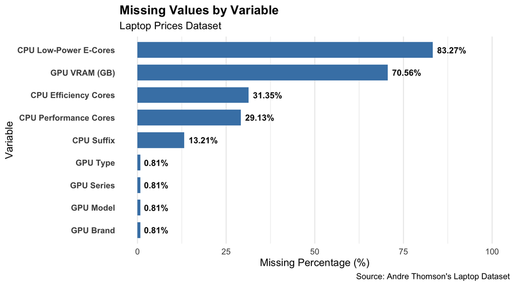

```r
ggplot(
  missing_summary,
  aes(
    x = reorder(variable, missing_percentage),
    y = missing_percentage
  )
) +
  geom_col(
    fill = "steelblue",
    width = 0.7
  ) +
  geom_text(
    aes(label = paste0(missing_percentage, "%")),
    hjust = -0.15,
    size = 3.8,
    fontface = "bold"
  ) +
  coord_flip() +
  scale_y_continuous(
    limits = c(0, 100)
  ) +
  labs(
    title = "Missing Values by Variable",
    subtitle = "Laptop Prices Dataset",
    x = "Variable",
    y = "Missing Percentage (%)",
    caption = "Source: Andre Thomson's Laptop Dataset"
  ) +
  theme_minimal(base_size = 13) +
  theme(
    plot.title = element_text(face = "bold"),
    axis.text.y = element_text(face = "bold"),
    panel.grid.major.y = element_blank()
  )
```

# 7 Data Cleaning and Transformation

In this section, I use Tidyverse functions to prepare the data for further analysis.

The original dataset remains unchanged.

## 7.1 Select Variables and Standardize Names

The `select()` function keeps the variables needed for this analysis. The `mutate()` function is used to standardize laptop brand names.

```r
# Select the main variables
laptops_clean <- laptops_raw |>
  select(
    brand,
    model,
    device_category,
    price,
    ram_gb,
    storage_gb,
    cpu_core_count
  ) |>
  mutate(
    brand = str_to_title(brand),
    brand = recode(
      brand,
      "Hp" = "HP",
      "Asus" = "ASUS",
      "Msi" = "MSI"
    )
  )

# Display the selected variables
knitr::kable(
  head(laptops_clean, 10),
  col.names = c(
    "Brand",
    "Laptop Model",
    "Device Category",
    "Price (INR)",
    "RAM (GB)",
    "Storage (GB)",
    "CPU Cores"
  ),
  caption = "Selected Laptop Variables",
  row.names = FALSE,
  format.args = list(big.mark = ",")
)
```

Selected Laptop Variables

| Brand | Laptop Model | Device Category | Price (INR) | RAM (GB) | Storage (GB) | CPU Cores |
| --- | --- | --- | --- | --- | --- | --- |
| Lenovo | Lenovo Legion Pro 5 16IAX10 83F3007CIN Gaming | Gaming | 189,990 | 32 | 1,024 | 20 |
| Lenovo | Lenovo IdeaPad Slim 3 83K100HSIN | Thin & Light | 62,350 | 16 | 1,024 | 8 |
| ASUS | Asus Vivobook Go 15 E1504FA-BQ2343WS | Thin & Light | 34,990 | 16 | 512 | 4 |
| Lenovo | Lenovo V14 G3 82TS00JGUS | General | 56,990 | 16 | 512 | 10 |
| Dell | Dell DC 14250 ODC1425000401RINS1 | General | 69,990 | 16 | 512 | 10 |
| Dell | Dell 14 Inspiron 5440 (100UU / 16GB / 512GB / Windows) | General | 37,800 | 16 | 512 | 6 |
| Lenovo | Lenovo V14 G4 82YTA00UIN | General | 29,990 | 8 | 512 | 4 |
| Acer | Acer TravelLite TL04-41M | General | 33,990 | 8 | 512 | 6 |
| HP | HP Victus 15-fa2303tx Gaming | Gaming | 82,999 | 24 | 512 | 10 |
| HP | HP Victus 15-fa1082wm Gaming | Gaming | 79,990 | 16 | 512 | 8 |

## 7.2 Currency Conversion (INR to USD)

The original laptop prices are in Indian Rupees (INR). I use the `mutate()` function to create a new variable with prices in US Dollars (USD).

The conversion uses the 2025 average exchange rate of 87.1468 INR per USD.

```r
# Set the 2025 average exchange rate
exchange_rate <- 87.1468

# Convert laptop prices to US Dollars
laptops_clean <- laptops_clean |>
  mutate(
    price_usd = price / exchange_rate
  ) |>
  relocate(price_usd, .after = price)

# Display the converted prices
laptops_clean |>
  head(10) |>
  mutate(
    price = scales::comma(price),
    price_usd = scales::dollar(price_usd, accuracy = 0.01)
  ) |>
  knitr::kable(
    col.names = c(
      "Brand",
      "Laptop Model",
      "Device Category",
      "Price (INR)",
      "Price (USD)",
      "RAM (GB)",
      "Storage (GB)",
      "CPU Cores"
    ),
    caption = "Laptop Prices in INR and USD",
    row.names = FALSE
  )
```

Laptop Prices in INR and USD

| Brand | Laptop Model | Device Category | Price (INR) | Price (USD) | RAM (GB) | Storage (GB) | CPU Cores |
| --- | --- | --- | --- | --- | --- | --- | --- |
| Lenovo | Lenovo Legion Pro 5 16IAX10 83F3007CIN Gaming | Gaming | 189,990 | $2,180.11 | 32 | 1024 | 20 |
| Lenovo | Lenovo IdeaPad Slim 3 83K100HSIN | Thin & Light | 62,350 | $715.46 | 16 | 1024 | 8 |
| ASUS | Asus Vivobook Go 15 E1504FA-BQ2343WS | Thin & Light | 34,990 | $401.51 | 16 | 512 | 4 |
| Lenovo | Lenovo V14 G3 82TS00JGUS | General | 56,990 | $653.95 | 16 | 512 | 10 |
| Dell | Dell DC 14250 ODC1425000401RINS1 | General | 69,990 | $803.13 | 16 | 512 | 10 |
| Dell | Dell 14 Inspiron 5440 (100UU / 16GB / 512GB / Windows) | General | 37,800 | $433.75 | 16 | 512 | 6 |
| Lenovo | Lenovo V14 G4 82YTA00UIN | General | 29,990 | $344.13 | 8 | 512 | 4 |
| Acer | Acer TravelLite TL04-41M | General | 33,990 | $390.03 | 8 | 512 | 6 |
| HP | HP Victus 15-fa2303tx Gaming | Gaming | 82,999 | $952.40 | 24 | 512 | 10 |
| HP | HP Victus 15-fa1082wm Gaming | Gaming | 79,990 | $917.88 | 16 | 512 | 8 |

Source: [Federal Reserve Economic Data (FRED)](https://fred.stlouisfed.org/series/AEXINUS).

## 7.3 Interpretation

I used `select()` to keep the main variables and `mutate()` to standardize brand names and convert prices to US Dollars.

I also used `relocate()` to place both price variables next to each other.

This transformation makes the prices easier to understand and compare. The USD values are estimates of the original prices in India.

# 8 Laptop Price Analysis by Brand

In this section, I compare laptop prices across different brands.

The `group_by()` and `summarise()` functions are used to calculate the number of laptops and their average, median, minimum, and maximum prices.

## 8.1 Price Summary by Brand

```r
# Calculate price statistics by brand
brand_summary <- laptops_clean |>
  group_by(brand) |>
  summarise(
    total_laptops = n(),
    average_price = mean(price_usd),
    median_price = median(price_usd),
    minimum_price = min(price_usd),
    maximum_price = max(price_usd),
    .groups = "drop"
  ) |>
  arrange(desc(median_price))

# Display the price summary
brand_summary |>
  mutate(
    across(
      ends_with("_price"),
      ~ scales::dollar(.x, accuracy = 0.01)
    )
  ) |>
  knitr::kable(
    col.names = c(
      "Brand",
      "Total Laptops",
      "Average Price (USD)",
      "Median Price (USD)",
      "Minimum Price (USD)",
      "Maximum Price (USD)"
    ),
    caption = "Laptop Price Summary by Brand",
    row.names = FALSE
  )
```

Laptop Price Summary by Brand

| Brand | Total Laptops | Average Price (USD) | Median Price (USD) | Minimum Price (USD) | Maximum Price (USD) |
| --- | --- | --- | --- | --- | --- |
| Alienware | 7 | $3,418.60 | $3,637.43 | $1,503.10 | $4,756.23 |
| Apple | 22 | $2,042.06 | $1,861.17 | $1,077.49 | $4,015.06 |
| Microsoft | 11 | $1,722.20 | $1,652.48 | $1,021.15 | $2,571.51 |
| Samsung | 17 | $1,451.14 | $1,549.10 | $401.51 | $2,248.96 |
| Colorful | 2 | $1,091.25 | $1,091.25 | $1,035.02 | $1,147.48 |
| MSI | 93 | $1,420.60 | $1,032.63 | $349.75 | $6,953.67 |
| Gigabyte | 7 | $1,094.06 | $998.20 | $819.30 | $1,950.73 |
| Dell | 73 | $1,137.04 | $803.13 | $373.74 | $5,427.51 |
| ASUS | 179 | $971.73 | $770.40 | $172.11 | $5,163.59 |
| Lenovo | 233 | $889.66 | $768.70 | $172.01 | $3,442.46 |
| HP | 218 | $885.95 | $746.68 | $296.55 | $3,557.10 |
| Motorola | 5 | $773.29 | $745.75 | $631.00 | $975.25 |
| Acer | 102 | $722.51 | $579.37 | $183.48 | $2,639.21 |
| Chuwi | 3 | $390.03 | $458.88 | $229.38 | $481.83 |
| Infinix | 10 | $567.32 | $450.27 | $344.13 | $1,135.90 |
| Air | 1 | $344.13 | $344.13 | $344.13 | $344.13 |
| Thomson | 4 | $265.92 | $262.19 | $154.99 | $384.29 |
| Ultimus | 4 | $239.76 | $235.12 | $143.32 | $345.50 |
| Walker | 1 | $194.96 | $194.96 | $194.96 | $194.96 |

## 8.2 Top 10 Most Common Laptop Brands

The `slice_max()` function selects the ten brands with the highest number of laptop records.

```r
# Select the ten most common brands
top_brands <- brand_summary |>
  slice_max(
    order_by = total_laptops,
    n = 10,
    with_ties = FALSE
  ) |>
  arrange(desc(total_laptops))

# Display the most common brands
top_brands |>
  select(
    brand,
    total_laptops,
    average_price,
    median_price
  ) |>
  mutate(
    across(
      ends_with("_price"),
      ~ scales::dollar(.x, accuracy = 0.01)
    )
  ) |>
  knitr::kable(
    col.names = c(
      "Brand",
      "Total Laptops",
      "Average Price (USD)",
      "Median Price (USD)"
    ),
    caption = "Top 10 Most Common Laptop Brands",
    row.names = FALSE
  )
```

Top 10 Most Common Laptop Brands

| Brand | Total Laptops | Average Price (USD) | Median Price (USD) |
| --- | --- | --- | --- |
| Lenovo | 233 | $889.66 | $768.70 |
| HP | 218 | $885.95 | $746.68 |
| ASUS | 179 | $971.73 | $770.40 |
| Acer | 102 | $722.51 | $579.37 |
| MSI | 93 | $1,420.60 | $1,032.63 |
| Dell | 73 | $1,137.04 | $803.13 |
| Apple | 22 | $2,042.06 | $1,861.17 |
| Samsung | 17 | $1,451.14 | $1,549.10 |
| Microsoft | 11 | $1,722.20 | $1,652.48 |
| Infinix | 10 | $567.32 | $450.27 |

## 8.3 Median Laptop Price by Brand

The median price is used because it is less affected by very high or very low prices.

The `fct_reorder()` function organizes the brands based on their median prices.

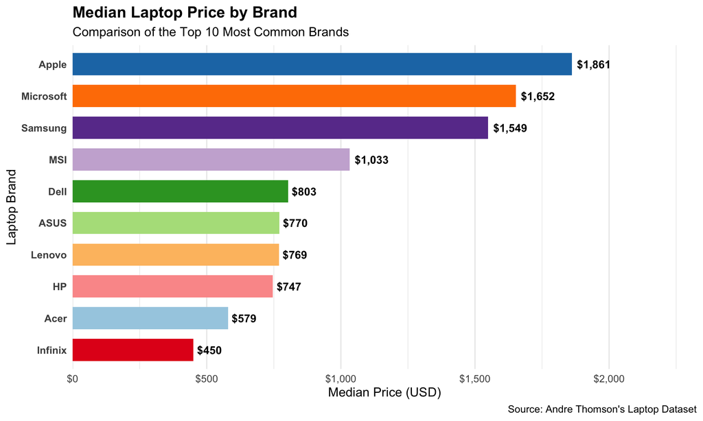

```r
ggplot(
  top_brands,
  aes(
    x = fct_reorder(brand, median_price),
    y = median_price,
    fill = brand
  )
) +
  geom_col(
    width = 0.7,
    show.legend = FALSE
  ) +
  geom_text(
    aes(
      label = scales::dollar(
        median_price,
        accuracy = 1
      )
    ),
    hjust = -0.15,
    size = 4,
    fontface = "bold"
  ) +
  coord_flip() +
  scale_y_continuous(
    labels = scales::label_dollar(),
    expand = expansion(mult = c(0, 0.25))
  ) +
  scale_fill_brewer(palette = "Paired") +
  labs(
    title = "Median Laptop Price by Brand",
    subtitle = "Comparison of the Top 10 Most Common Brands",
    x = "Laptop Brand",
    y = "Median Price (USD)",
    caption = "Source: Andre Thomson's Laptop Dataset"
  ) +
  theme_minimal(base_size = 13) +
  theme(
    plot.title = element_text(face = "bold", size = 16),
    axis.text.y = element_text(face = "bold"),
    panel.grid.major.y = element_blank()
  )
```

# 9 RAM and Laptop Price Analysis

In this section, I explore how laptop prices vary by RAM capacity.

I use the `group_by()` and `summarise()` functions to compare laptop prices across different RAM sizes.

## 9.1 Price Summary by RAM Capacity

```r
# Calculate price statistics by RAM capacity
ram_summary <- laptops_clean |>
  group_by(ram_gb) |>
  summarise(
    total_laptops = n(),
    average_price = mean(price_usd),
    median_price = median(price_usd),
    minimum_price = min(price_usd),
    maximum_price = max(price_usd),
    .groups = "drop"
  ) |>
  arrange(ram_gb)

# Display the RAM price summary
ram_summary |>
  mutate(
    ram_gb = paste(ram_gb, "GB"),
    across(
      ends_with("_price"),
      ~ scales::dollar(.x, accuracy = 0.01)
    )
  ) |>
  knitr::kable(
    col.names = c(
      "RAM Capacity",
      "Total Laptops",
      "Average Price (USD)",
      "Median Price (USD)",
      "Minimum Price (USD)",
      "Maximum Price (USD)"
    ),
    caption = "Laptop Price Summary by RAM Capacity",
    row.names = FALSE
  )
```

Laptop Price Summary by RAM Capacity

| RAM Capacity | Total Laptops | Average Price (USD) | Median Price (USD) | Minimum Price (USD) | Maximum Price (USD) |
| --- | --- | --- | --- | --- | --- |
| 4 GB | 9 | $220.28 | $172.11 | $143.32 | $519.70 |
| 8 GB | 193 | $438.62 | $412.98 | $183.48 | $1,004.18 |
| 12 GB | 13 | $686.52 | $705.59 | $424.56 | $1,091.15 |
| 16 GB | 621 | $910.14 | $803.13 | $355.61 | $2,524.36 |
| 24 GB | 45 | $1,386.73 | $1,353.92 | $727.39 | $2,753.86 |
| 32 GB | 103 | $2,300.45 | $2,088.32 | $651.77 | $5,146.37 |
| 36 GB | 2 | $3,671.33 | $3,671.33 | $3,327.60 | $4,015.06 |
| 48 GB | 1 | $3,212.85 | $3,212.85 | $3,212.85 | $3,212.85 |
| 64 GB | 5 | $5,620.32 | $5,427.51 | $4,934.09 | $6,953.67 |

## 9.2 Laptop Price Distribution by RAM

The `geom_boxplot()` function shows the distribution of laptop prices for each RAM capacity.

This chart helps compare median prices, price variation, and unusually high or low prices.

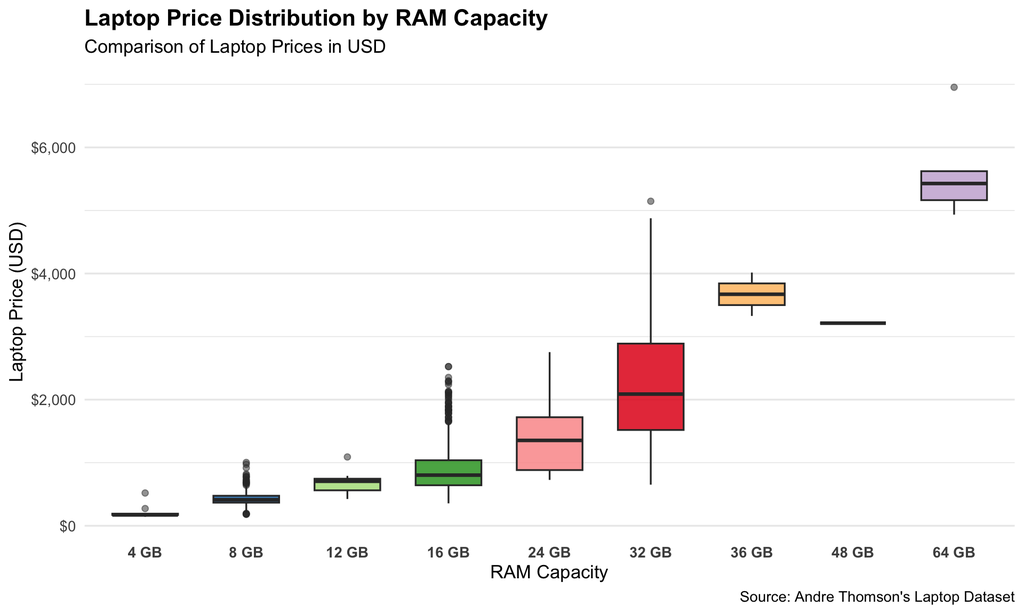

```r
ggplot(
  laptops_clean,
  aes(
    x = factor(ram_gb),
    y = price_usd,
    fill = factor(ram_gb)
  )
) +
  geom_boxplot(
    width = 0.65,
    alpha = 0.85,
    outlier.alpha = 0.5,
    show.legend = FALSE
  ) +
  scale_fill_brewer(
    palette = "Paired"
  ) +
  scale_y_continuous(
    labels = scales::label_dollar()
  ) +
  scale_x_discrete(
    labels = function(x) paste(x, "GB")
  ) +
  labs(
    title = "Laptop Price Distribution by RAM Capacity",
    subtitle = "Comparison of Laptop Prices in USD",
    x = "RAM Capacity",
    y = "Laptop Price (USD)",
    caption = "Source: Andre Thomson's Laptop Dataset"
  ) +
  theme_minimal(base_size = 13) +
  theme(
    plot.title = element_text(
      face = "bold",
      size = 16
    ),
    axis.text.x = element_text(face = "bold"),
    panel.grid.major.x = element_blank()
  )
```

# 10 Storage and Laptop Price Analysis

In this section, I explore how laptop prices vary by storage capacity.

I use the `case_when()` function to display storage capacity in GB or TB, making the results easier to understand.

## 10.1 Price Summary by Storage Capacity

```r
# Create readable storage capacity labels
laptops_clean <- laptops_clean |>
  mutate(
    storage_label = case_when(
      storage_gb >= 1024 ~ paste(storage_gb / 1024, "TB"),
      TRUE ~ paste(storage_gb, "GB")
    )
  )

# Calculate price statistics by storage capacity
storage_summary <- laptops_clean |>
  group_by(storage_gb, storage_label) |>
  summarise(
    total_laptops = n(),
    average_price = mean(price_usd),
    median_price = median(price_usd),
    minimum_price = min(price_usd),
    maximum_price = max(price_usd),
    .groups = "drop"
  ) |>
  arrange(storage_gb)

# Display the storage price summary
storage_summary |>
  select(-storage_gb) |>
  mutate(
    across(
      ends_with("_price"),
      ~ scales::dollar(.x, accuracy = 0.01)
    )
  ) |>
  knitr::kable(
    col.names = c(
      "Storage Capacity",
      "Total Laptops",
      "Average Price (USD)",
      "Median Price (USD)",
      "Minimum Price (USD)",
      "Maximum Price (USD)"
    ),
    caption = "Laptop Price Summary by Storage Capacity",
    row.names = FALSE
  )
```

Laptop Price Summary by Storage Capacity

| Storage Capacity | Total Laptops | Average Price (USD) | Median Price (USD) | Minimum Price (USD) | Maximum Price (USD) |
| --- | --- | --- | --- | --- | --- |
| 64 GB | 6 | $177.83 | $177.85 | $172.01 | $183.59 |
| 128 GB | 10 | $236.67 | $268.45 | $143.32 | $309.81 |
| 256 GB | 21 | $585.54 | $355.61 | $194.96 | $1,537.64 |
| 512 GB | 666 | $717.46 | $685.73 | $262.76 | $3,212.85 |
| 1 TB | 269 | $1,568.94 | $1,464.04 | $435.93 | $5,146.37 |
| 2 TB | 17 | $3,861.78 | $3,901.35 | $2,616.26 | $5,427.51 |
| 4 TB | 2 | $5,278.43 | $5,278.43 | $4,934.09 | $5,622.77 |
| 6 TB | 1 | $6,953.67 | $6,953.67 | $6,953.67 | $6,953.67 |

## 10.2 Median Laptop Price by Storage Capacity

The following chart compares median laptop prices across different storage capacities.

The `geom_point()` and `geom_line()` functions help show changes in median prices.

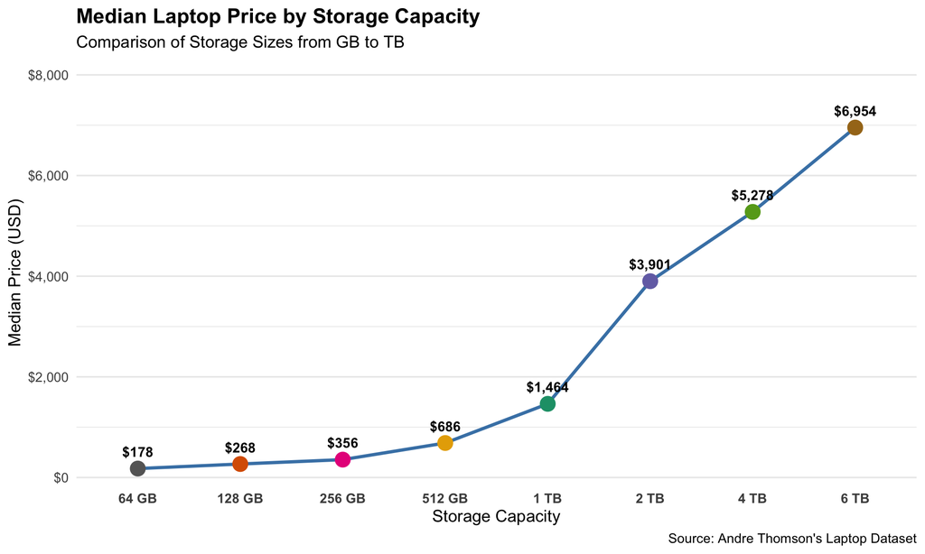

```r
ggplot(
  storage_summary,
  aes(
    x = fct_reorder(storage_label, storage_gb),
    y = median_price,
    group = 1
  )
) +
  geom_line(
    color = "steelblue",
    linewidth = 1.2
  ) +
  geom_point(
    aes(color = storage_label),
    size = 5,
    show.legend = FALSE
  ) +
  geom_text(
    aes(
      label = scales::dollar(
        median_price,
        accuracy = 1
      )
    ),
    vjust = -1.2,
    size = 3.8,
    fontface = "bold"
  ) +
  scale_color_brewer(palette = "Dark2") +
  scale_y_continuous(
    labels = scales::label_dollar(),
    expand = expansion(mult = c(0.05, 0.20))
  ) +
  labs(
    title = "Median Laptop Price by Storage Capacity",
    subtitle = "Comparison of Storage Sizes from GB to TB",
    x = "Storage Capacity",
    y = "Median Price (USD)",
    caption = "Source: Andre Thomson's Laptop Dataset"
  ) +
  theme_minimal(base_size = 13) +
  theme(
    plot.title = element_text(
      face = "bold",
      size = 16
    ),
    axis.text.x = element_text(face = "bold"),
    panel.grid.major.x = element_blank()
  )
```

# 11 CPU Core Count and Laptop Price Analysis

In this section, I explore the relationship between the number of CPU cores and laptop prices.

The purpose is to identify whether laptops with more CPU cores tend to have higher prices.

## 11.1 Price Summary by CPU Core Count

```r
# Calculate price statistics by CPU core count
cpu_summary <- laptops_clean |>
  group_by(cpu_core_count) |>
  summarise(
    total_laptops = n(),
    average_price = mean(price_usd),
    median_price = median(price_usd),
    minimum_price = min(price_usd),
    maximum_price = max(price_usd),
    .groups = "drop"
  ) |>
  arrange(cpu_core_count)

# Display the CPU price summary
cpu_summary |>
  mutate(
    across(
      ends_with("_price"),
      ~ scales::dollar(.x, accuracy = 0.01)
    )
  ) |>
  knitr::kable(
    col.names = c(
      "CPU Cores",
      "Total Laptops",
      "Average Price (USD)",
      "Median Price (USD)",
      "Minimum Price (USD)",
      "Maximum Price (USD)"
    ),
    caption = "Laptop Price Summary by CPU Core Count",
    row.names = FALSE
  )
```

Laptop Price Summary by CPU Core Count

| CPU Cores | Total Laptops | Average Price (USD) | Median Price (USD) | Minimum Price (USD) | Maximum Price (USD) |
| --- | --- | --- | --- | --- | --- |
| 2 | 38 | $266.54 | $271.35 | $143.32 | $519.70 |
| 4 | 55 | $468.77 | $401.51 | $296.55 | $826.08 |
| 5 | 16 | $419.49 | $424.46 | $355.61 | $475.75 |
| 6 | 158 | $481.77 | $435.93 | $275.28 | $894.93 |
| 8 | 249 | $927.15 | $785.92 | $355.61 | $2,421.09 |
| 10 | 240 | $883.67 | $803.13 | $345.50 | $2,329.29 |
| 12 | 49 | $1,470.00 | $1,296.55 | $573.63 | $3,155.48 |
| 14 | 52 | $1,224.95 | $986.73 | $665.43 | $4,015.06 |
| 16 | 89 | $1,813.32 | $1,560.47 | $836.52 | $5,146.37 |
| 20 | 15 | $2,020.75 | $1,893.35 | $1,239.17 | $3,442.35 |
| 24 | 31 | $3,537.45 | $3,442.35 | $1,618.14 | $6,953.67 |

## 11.2 CPU Core Count vs. Laptop Price

The `geom_point()` function displays individual laptop prices, while `geom_smooth()` adds a trend line.

Different colors represent different laptop categories.

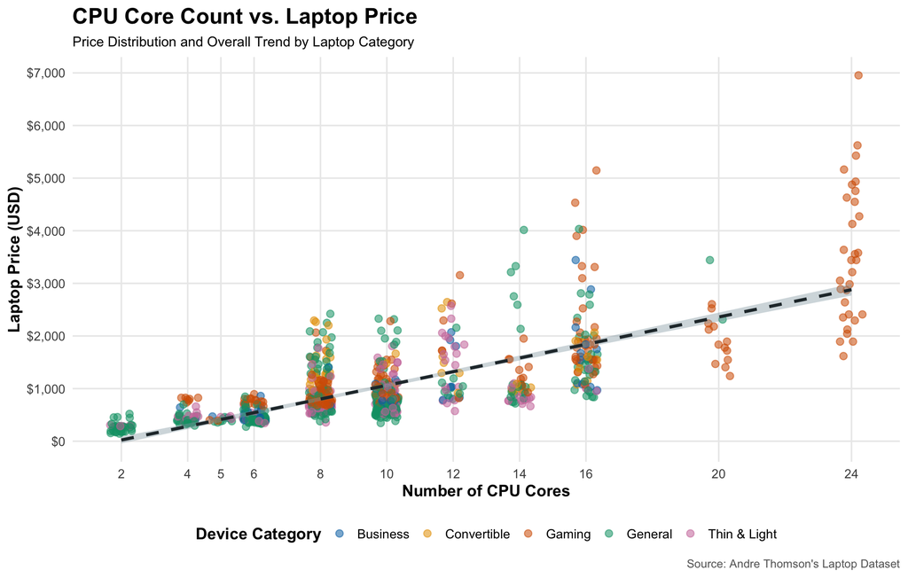

```r
ggplot(
  laptops_clean,
  aes(
    x = cpu_core_count,
    y = price_usd
  )
) +
  geom_point(
    aes(color = device_category),
    size = 2.6,
    alpha = 0.55,
    position = position_jitter(
      width = 0.35,
      height = 0,
      seed = 123
    )
  ) +

  # Add the overall trend line
  geom_smooth(
    method = "lm",
    formula = y ~ x,
    color = "#263238",
    fill = "#90A4AE",
    linewidth = 1.3,
    linetype = "dashed",
    se = TRUE
  ) +

  # Assign a color to each laptop category
  scale_color_manual(
    values = c(
      "Business" = "#0072B2",
      "Convertible" = "#E69F00",
      "Gaming" = "#D55E00",
      "General" = "#009E73",
      "Thin & Light" = "#CC79A7"
    )
  ) +

  # Display actual CPU core counts
  scale_x_continuous(
    breaks = sort(unique(laptops_clean$cpu_core_count))
  ) +

  scale_y_continuous(
    labels = scales::label_dollar(),
    breaks = scales::breaks_width(1000)
  ) +

  labs(
    title = "CPU Core Count vs. Laptop Price",
    subtitle = "Price Distribution and Overall Trend by Laptop Category",
    x = "Number of CPU Cores",
    y = "Laptop Price (USD)",
    color = "Device Category",
    caption = "Source: Andre Thomson's Laptop Dataset"
  ) +

  theme_minimal(base_size = 14) +

  theme(
    plot.title = element_text(
      face = "bold",
      size = 19
    ),
    plot.subtitle = element_text(size = 12),
    axis.title = element_text(face = "bold"),
    axis.text = element_text(size = 11),
    legend.position = "bottom",
    legend.title = element_text(face = "bold"),
    panel.grid.minor = element_blank(),
    plot.caption = element_text(
      color = "gray40",
      size = 10
    )
  ) +
  guides(
    color = guide_legend(nrow = 1)
  )
```

## 11.3 Interpretation

The chart shows a positive relationship between CPU core count and laptop prices.

Laptops with more CPU cores generally have higher prices. Gaming laptops are also among the most expensive models.

However, laptops with the same number of CPU cores can have different prices. This suggests that other hardware specifications may also affect laptop prices.

# 12 Combined RAM and Storage Analysis

In this section, I analyze RAM and storage capacity together to compare laptop prices.

The purpose is to identify which hardware combinations are associated with higher or lower prices.

## 12.1 Price Summary by RAM and Storage

```r
# Calculate price statistics by RAM and storage
ram_storage_summary <- laptops_clean |>
  group_by(ram_gb, storage_gb, storage_label) |>
  summarise(
    total_laptops = n(),
    average_price = mean(price_usd),
    median_price = median(price_usd),
    .groups = "drop"
  ) |>
  arrange(ram_gb, storage_gb)

# Display the combined price summary
ram_storage_summary |>
  select(-storage_gb) |>
  mutate(
    ram_gb = paste(ram_gb, "GB"),
    across(
      ends_with("_price"),
      ~ scales::dollar(.x, accuracy = 0.01)
    )
  ) |>
  knitr::kable(
    col.names = c(
      "RAM Capacity",
      "Storage Capacity",
      "Total Laptops",
      "Average Price (USD)",
      "Median Price (USD)"
    ),
    caption = "Laptop Prices by RAM and Storage",
    row.names = FALSE
  )
```

Laptop Prices by RAM and Storage

| RAM Capacity | Storage Capacity | Total Laptops | Average Price (USD) | Median Price (USD) |
| --- | --- | --- | --- | --- |
| 4 GB | 64 GB | 4 | $174.95 | $172.11 |
| 4 GB | 128 GB | 4 | $190.76 | $173.31 |
| 4 GB | 256 GB | 1 | $519.70 | $519.70 |
| 8 GB | 64 GB | 2 | $183.59 | $183.59 |
| 8 GB | 128 GB | 6 | $267.28 | $279.92 |
| 8 GB | 256 GB | 12 | $293.23 | $272.44 |
| 8 GB | 512 GB | 171 | $455.50 | $418.82 |
| 8 GB | 1 TB | 2 | $636.28 | $636.28 |
| 12 GB | 512 GB | 13 | $686.52 | $705.59 |
| 16 GB | 256 GB | 8 | $1,032.24 | $1,141.14 |
| 16 GB | 512 GB | 451 | $777.87 | $745.75 |
| 16 GB | 1 TB | 162 | $1,272.36 | $1,178.93 |
| 24 GB | 512 GB | 24 | $1,233.12 | $1,075.66 |
| 24 GB | 1 TB | 21 | $1,562.29 | $1,491.62 |
| 32 GB | 512 GB | 6 | $1,231.37 | $837.55 |
| 32 GB | 1 TB | 82 | $2,128.04 | $1,976.78 |
| 32 GB | 2 TB | 15 | $3,670.61 | $3,442.35 |
| 36 GB | 1 TB | 2 | $3,671.33 | $3,671.33 |
| 48 GB | 512 GB | 1 | $3,212.85 | $3,212.85 |
| 64 GB | 2 TB | 2 | $5,295.55 | $5,295.55 |
| 64 GB | 4 TB | 2 | $5,278.43 | $5,278.43 |
| 64 GB | 6 TB | 1 | $6,953.67 | $6,953.67 |

## 12.2 RAM and Storage Price Heatmap

The `geom_tile()` function creates a heatmap to compare median prices across different combinations of RAM and storage.

Darker colors represent higher median prices. Each cell also shows the median price and the number of laptop records.

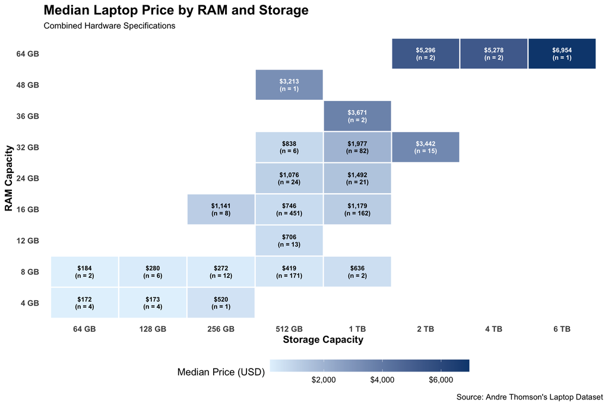

```r
ggplot(
  ram_storage_summary,
  aes(
    x = fct_reorder(storage_label, storage_gb),
    y = factor(ram_gb),
    fill = median_price
  )
) +

  # Create the heatmap
  geom_tile(
    color = "white",
    linewidth = 0.8
  ) +

  # Display median prices and record counts
  geom_text(
    aes(
      label = paste0(
        scales::dollar(median_price, accuracy = 1),
        "\n(n = ", total_laptops, ")"
      ),
      color = median_price > 2000
    ),
    size = 3.2,
    fontface = "bold",
    lineheight = 0.95
  ) +

  # Set the price color scale
  scale_fill_gradient(
    low = "#E3F2FD",
    high = "#0D477D",
    labels = scales::label_dollar()
  ) +

  scale_color_manual(
    values = c("FALSE" = "black", "TRUE" = "white"),
    guide = "none"
  ) +

  scale_y_discrete(
    labels = function(x) paste(x, "GB")
  ) +

  labs(
    title = "Median Laptop Price by RAM and Storage",
    subtitle = "Combined Hardware Specifications",
    x = "Storage Capacity",
    y = "RAM Capacity",
    fill = "Median Price (USD)",
    caption = "Source: Andre Thomson's Laptop Dataset"
  ) +

  theme_minimal(base_size = 14) +

  theme(
    plot.title = element_text(
      face = "bold",
      size = 19
    ),
    plot.subtitle = element_text(size = 12),
    axis.title = element_text(face = "bold"),
    axis.text = element_text(face = "bold"),
    panel.grid = element_blank(),
    legend.position = "bottom",
    legend.key.width = grid::unit(2, "cm")
  )
```

# 13 Results and Discussion

This extension uses additional Tidyverse functions to explore laptop prices based on brand, RAM, storage capacity, and CPU core count.

## 13.1 Overall Laptop Summary

```r
# Calculate the main dataset statistics
overall_summary <- tibble(
  Description = c(
    "Total Laptop Records",
    "Total Laptop Brands",
    "Total Device Categories",
    "Average Price (USD)",
    "Median Price (USD)",
    "Minimum Price (USD)",
    "Maximum Price (USD)"
  ),
  Value = c(
    scales::comma(nrow(laptops_clean)),
    n_distinct(laptops_clean$brand),
    n_distinct(laptops_clean$device_category),
    scales::dollar(mean(laptops_clean$price_usd)),
    scales::dollar(median(laptops_clean$price_usd)),
    scales::dollar(min(laptops_clean$price_usd)),
    scales::dollar(max(laptops_clean$price_usd))
  )
)

knitr::kable(
  overall_summary,
  col.names = c("Dataset Information", "Value"),
  caption = "Overall Laptop Dataset Summary",
  row.names = FALSE
)
```

Overall Laptop Dataset Summary

| Dataset Information | Value |
| --- | --- |
| Total Laptop Records | 992 |
| Total Laptop Brands | 19 |
| Total Device Categories | 5 |
| Average Price (USD) | $1,006.82 |
| Median Price (USD) | $780.18 |
| Minimum Price (USD) | $143.32 |
| Maximum Price (USD) | $6,953.67 |

## 13.2 Tidyverse Functions Used in This Extension

The following table summarizes the main functions used to extend the original vignette.

Tidyverse Functions Used in the Extension

| Function | Package | Purpose |
| --- | --- | --- |
| mutate() | dplyr | Convert prices from INR to USD. |
| relocate() | dplyr | Organize price columns. |
| case_when() | dplyr | Create GB and TB storage labels. |
| slice_max() | dplyr | Identify the most common brands. |
| fct_reorder() | forcats | Organize chart categories. |
| geom_boxplot() | ggplot2 | Compare price distributions. |
| geom_smooth() | ggplot2 | Show the overall price trend. |
| geom_tile() | ggplot2 | Compare RAM and storage together. |

## 13.3 Discussion

The original vignette focused on laptop categories and basic hardware requirements.

This extension provides a more detailed analysis of laptop prices by brand, RAM, storage capacity, and CPU core count.

The conversion from INR to USD makes the prices easier to understand.

The different tables and visualizations help compare hardware specifications and identify price patterns.

The CPU analysis shows that laptops with more CPU cores generally have higher prices. However, price differences may also depend on other specifications and device categories.

## 13.4 Limitations

This analysis has some limitations:

- The dataset represents the laptop market in India.
- Prices in USD are estimated using an average exchange rate.
- Some hardware combinations have fewer laptop records.
- Other factors, such as GPU performance and processor generation, may also be related to laptop prices.
- The results show relationships between variables but do not prove causation.

# 14 Conclusion

In this project, I extended Andre Thomson’s original vignette using additional Tidyverse functions.

I converted laptop prices from INR to USD and explored the relationship between prices and different hardware specifications.

I also created additional tables, bar charts, boxplots, a scatter plot, and a heatmap.

This assignment helped me better understand how Tidyverse functions work together to clean, transform, summarize, and visualize real-world data.

It also helped me practice collaboration with GitHub by building on another student’s work.

# 15 AI Use

ChatGPT was used to help understand the assignment requirements, review the original vignette, organize the extension, improve the English writing, and provide guidance on R code and Tidyverse functions.

I reviewed the code, tables, and visualizations during the development of this extension.

# 16 References

- Thomson, A. (2026). [Laptop Prices with Tidyverse](https://github.com/DW8888/fall2027-data607-tidyverse-assignment/blob/main/Andre_Thomson_Laptop_Prices_Tidyverse.qmd).
- Kaggle. [Laptops Cleaned Dataset](https://www.kaggle.com/datasets/githubmasterin/laptops-cleaned-dataset).
- [Tidyverse Documentation](https://www.tidyverse.org/).
- [ggplot2 Documentation](https://ggplot2.tidyverse.org/).
- Federal Reserve Economic Data (FRED). [Indian Rupees to U.S. Dollar Annual Exchange Rate](https://fred.stlouisfed.org/series/AEXINUS).